# Non-violence and NAVCO

## NAVCO Data

We’ll use Chenoweth’s NAVCO data to look at the relationship between non-violence and movement outcomes. The project data is available through the Harvard Dataverse.

There are currently multiple different versions of the data. Her 2008 paper used data from Version 1.1.

```r
library(tidyverse)
library(dataverse)
library(paletteer)
library(gtsummary)

# loading NAVCO version 1.1
navco1_raw <- get_dataframe_by_name(
  filename = 'NAVCO 1.1.tab',
  dataset = 'doi:10.7910/DVN/YLLHEE',
  server = 'dataverse.harvard.edu',
  original = TRUE,
  .f = haven::read_dta
)
```

We’ll do some recoding to the raw data to get it in a usable format for analysis:

```r
navco1 <- navco1_raw |>
  mutate(
    defect = factor(
      defect,
      levels = c(0, 1),
      labels = c("No security force defections", "Security force defections")
    ),
    outcome = factor(
      outcome,
      levels = c(3, 4, 5),
      labels = c("Failure", "Partial success", "Success")
    ),
    regaid = factor(
      regaid,
      levels = c(0, 1),
      labels = c(
        "Regime did not recieve state support",
        "Regime recieved state support"
      )
    ),
    regviol = factor(
      regviol,
      levels = c(0, 1),
      labels = c("No major regime repression;", "Major regime repression")
    ),
    viol = factor(
      viol,
      levels = c(0, 1),
      labels = c("Primarily non-violent", "Primarily violent")
    ),
    nonviol = factor(
      nonviol,
      levels = c(0, 1),
      labels = c("Primarily violent", "Primarily non-violent")
    ),
    violsim = factor(
      violsim,
      levels = c(0, 1),
      labels = c("No violent flank", "Violent flank")
    ),
    statesup = factor(
      statesup,
      levels = c(0, 1),
      labels = c("No state support", "State support")
    ),
    sdirect = factor(
      sdirect,
      levels = c(0 , 1),
      labels = c("No sanctions", "Sanctions")
    ),
    goals = case_when(
      secession == 1 ~ "Secesson",
      fselfdet == 1 ~ "Self-determination",
      regchange == 1 ~ "Regime change",
      other == 1 ~ "Other"
    ),
    time_period = case_when(eyear >=1949  & eyear <=1991 ~ "Cold War",
                            eyear >1991 ~ "post-Cold War",
                            .default = "Pre-Cold War"
                            )|>
      factor(levels= c("Pre-Cold War", "Cold War", "post-Cold War"))
    )
```

## Comparisons: violent and non-violent campaigns

How do the outcomes compare for non-violent and violent campaigns? We can get a sense for the relationship here by calculating the proportion of success/partial success/ and failure for each type of campaign:

```r
outcome_counts<-navco1|>
  count(outcome, nonviol)|>
  group_by(nonviol)|>
  mutate(proportion = n / sum(n))
```

We can use a bar plot to visualize our results:

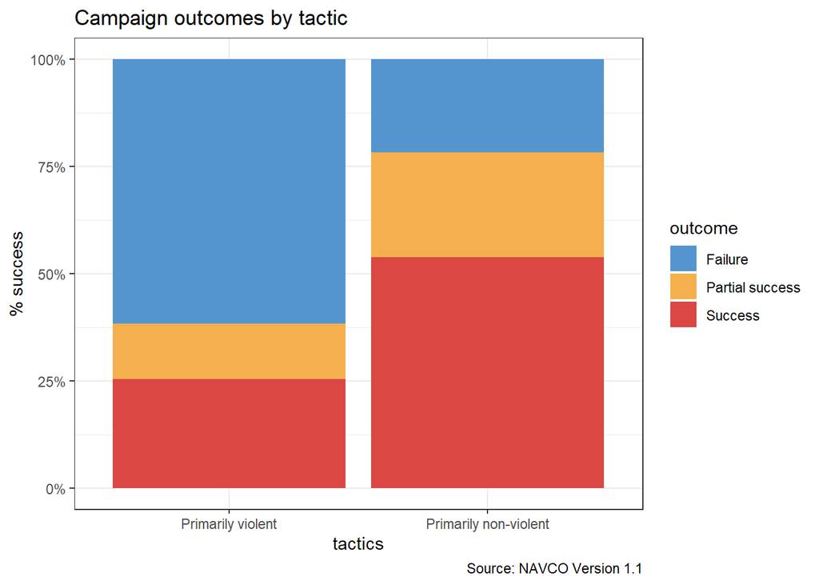

```r
ggplot(outcome_counts, aes(x=nonviol, y=proportion, fill = outcome)) +
  geom_bar(stat='identity') +
  theme_bw() +
  scale_y_continuous(labels = scales::percent) +
  labs(x = "tactics",
       y = '% success',
       title ='Campaign outcomes by tactic',
       caption = 'Source: NAVCO Version 1.1'
       ) +
  scale_fill_paletteer_d("nationalparkcolors::Badlands")
```

One question that might arise here is whether the difference in outcomes is statistically distinguishable from what we might see as the result of random chance. Since our outcomes here are all categorical, we can use a $\chi^2$ test to calculate the probability of seeing this distribution of outcomes if there is no relationship between movement tactics and outcomes.

One way to do this is by creating a cross tab and then using the `chisq.test` function:

```r
table(navco1$nonviol, navco1$outcome)|>
  chisq.test()
```

```
    Pearson's Chi-squared test

data:  table(navco1$nonviol, navco1$outcome)
X-squared = 45.858, df = 2, p-value = 1.102e-10
```

Alternatively, we can create a formatted version of this table by using `add_p` with `tbl_summary` (both commands from the [`gtsummary`](https://www.danieldsjoberg.com/gtsummary/index.html) package.)

```r
navco1|>
  select(nonviol, outcome)|>
  tbl_summary(by=nonviol)|>
  add_p()
```

| **Characteristic** | **Primarily violent** N = 217<sup>1</sup> | **Primarily non-violent** N = 106<sup>1</sup> | **p-value**<sup>2</sup> |
| --- | --- | --- | --- |
| outcome |  |  | <0.001 |
| Failure | 134 (62%) | 23 (22%) |  |
| Partial success | 28 (13%) | 26 (25%) |  |
| Success | 55 (25%) | 57 (54%) |  |

<sup>1</sup> n (%)  
<sup>2</sup> Pearson’s Chi-squared test

## Tactics and defections

How do violence and non-violence relate to the probability of security force defections (`defect`) in this data? Is the relationship statistically significant?

## Controlled comparison: simultaneous violent movements

Does the presence of a violent flank within a non-violent movement influence the probability of success? Re-examine the relationship of non-violence on movement success separately for movements with and without a simultaneous violent movement (`violsim`)

## Multinomial logistic regression

Chenoweth uses multinomial logistic regression to examine the effects of tactics while controlling for multiple movement characteristics.

Recall that logistic regression models outcomes using the logged odds, or the probability that Y = 1 compared to the probability that Y = 0:

$$\text{log odds = \text{ln}\frac{p}{1-p}$$

To convert log odds to a predicted probabilities for a given model, we would use this formula:

$$\text{Pr}(Y=1|\beta_0 + B_1X_1 + B_2X_2...) = \frac{e^{(\beta_0 + B_1X_1 + B_2X_2...)}}{1+ e^{(\beta_0 + B_1X_1 + B_2X_2...)}}$$

By contrast, a multinomial regression models model outcomes using the logged ratio of $Y = k$ compared to the probability that $Y = j$, where “$j$” is some excluded baseline category.

$$\text{ln}\frac{p_k}{p_j}$$
To convert this back into a set of probabilities, we could use this formula:

$$\text{Pr}(Y=k|\beta_0 + B_{k1}X_1 + B_{k2}X_2...) = \frac{e^{(\beta_0 + B_{k1}X_1 + B_{k2}X_2...)}}{1 + \sum^{K-1}_{j=1} e^{(\beta_0 + B_{j1}X_1 + B_{j2}X_2...)}}$$

Exponentiating the value of a coefficient from a multinomial logit would give us the multiplicative change in the relative risk for each one unit change in $x$.

### Running a multinomial logit

```r
library(nnet)
model<-multinom(outcome ~
                  nonviol,
         data=navco1)
```

To interpret these as ratios, we can exponentiate the coefficients. (For the sake of readability, I’m also using `t()` to transpose the results)

```r
exp(coef(model))|>t()
```

```
                             Partial success   Success
(Intercept)                        0.2089579 0.4104519
nonviolPrimarily non-violent       5.4096270 6.0378033
```

### Probability of failure

```r
xvalues<-c(1, 1) # constant term + non-violence = 1


denom<-1 + exp(coef(model)[1,] %*% xvalues)  + exp(coef(model)[2,] %*% xvalues)

failure<-1/denom

failure
```

```
          [,1]
[1,] 0.2169851
```

### Partial success

```r
num<-exp(coef(model)[1,] %*% xvalues)

denom<-1 + exp(coef(model)[1,] %*% xvalues)  + exp(coef(model)[2,] %*% xvalues)

# probability of partial success
partial_success<-num/denom
partial_success
```

```
          [,1]
[1,] 0.2452765
```

### Full success

```r
num<-exp(coef(model)[2,] %*%  xvalues)


denom<-1 + exp(coef(model)[1,] %*% xvalues)  + exp(coef(model)[2,] %*% xvalues)

# probability of success:
success<-num/denom

success
```

```
          [,1]
[1,] 0.5377384
```

### Using predict

we can also just the the “predict” function to do this all in one step:

```r
predict(model,
        newdata=data.frame(nonviol = "Primarily non-violent"),
        type='probs'
        )
```

```
        Failure Partial success         Success
      0.2169851       0.2452765       0.5377384
```

The relative risk ratio is the multiplicative change in the relative risk of success vs. failure for non-violent vs. violent campaigns:

```r
xvalues<-c(1, 0) # constant term + non-violence = 0
denom<-1 + exp(coef(model)[1,] %*% xvalues)  + exp(coef(model)[2,] %*% xvalues)
failure_0<-1/denom
num<-exp(coef(model)[2,] %*%  xvalues)
success_0<-num/denom


xvalues<-c(1, 1) # constant term + non-violence = 1
denom<-1 + exp(coef(model)[1,] %*% xvalues)  + exp(coef(model)[2,] %*% xvalues)
failure_1<-1/denom
num<-exp(coef(model)[2,] %*%  xvalues)
success_1<-num/denom


(success_1 /failure_1) / (success_0/failure_0)
```

```
         [,1]
[1,] 6.037803
```

```r
library(marginaleffects)

out<-avg_comparisons(model)
out
```

```
           Group Estimate Std. Error     z Pr(>|z|)    S  2.5 % 97.5 %
 Failure           -0.401     0.0519 -7.72   <0.001 46.3 -0.502 -0.299
 Partial success    0.116     0.0476  2.44   0.0146  6.1  0.023  0.210
 Success            0.284     0.0567  5.01   <0.001 20.8  0.173  0.395

Term: nonviol
Type: probs
Comparison: Primarily non-violent - Primarily violent
```

### Controlled multinomial logit

Use the code above as a jumping off point. Run the same model after including controls for sanctions (`sdirect`) and logged membership (`lmembers`). Does the marginal effect of non-violence change? Is the relationship still statistically significant at conventional levels?